# Digital Epidemiology 2018

## Assignment #1

### Alfonso D'Amelio (1658170), Daniele Mocavini (1475062), Dario Stagnitto (1669084)

### Library

```python
import pandas as pd
import matplotlib.pyplot as plt
import seaborn as sns
import matplotlib.ticker as plticker
import datetime
import warnings
warnings.filterwarnings("ignore")
import re
import requests
import bs4
from gensim.models import Word2Vec
from nltk.corpus import wordnet as wn
from sklearn.preprocessing import MinMaxScaler
from sklearn.linear_model import LinearRegression,Ridge, Lasso
from sklearn.ensemble import GradientBoostingRegressor
from sklearn.ensemble import RandomForestRegressor
from sklearn import metrics
import numpy as np
from sklearn.model_selection import train_test_split
from sklearn.model_selection import cross_val_score
from sklearn import kernel_ridge
from sklearn.metrics import mean_absolute_error
```

### Functions

```python
def iso_week(dataframe, col=0,year=2015,month=7,day=1):
    '''
    Convert in iso week creating a new column called "Date iso week" and sum views in the same iso week.
    Create also a new column with year
    col: data column, def=0
    year= starting year, def=2015
    month= starting month, def=7
    day=starting day, def=1
    '''

    dt = datetime.date(year,month,day)
    wk = dt.isocalendar()[1]
    dataframe['Date iso week']=pd.to_datetime(dataframe.iloc[:,col]).dt.strftime('%Y-%V')

    #sum views of the same iso week
    sum_iso_week=dataframe.groupby("Date iso week").sum()
    sum_iso_week=sum_iso_week.reset_index()

    #for the sak of simplicity add a column with year
    year=[]
    for i in sum_iso_week['Date iso week']:
        year.append(i[:4])
    sum_iso_week['year']=year

    return sum_iso_week
```

```python
def data_years(dataframe, year):
    '''
    Create a new data frame only for the inserted year
    '''
    year=str(year)
    dataframe=dataframe.loc[(dataframe["year"]==year)]

    return dataframe
```

```python
def plot(dataframe,label2,label1="Date iso week", title=1,typ=0,model_name=None):
    '''
    Plot dataframes and calculate Pearson correlation
    '''
    if typ==0:
        label2=str(label2)

        plt.figure(figsize=(14,6))
        sns.set_style("darkgrid")

        plt.plot('Date iso week', label2, data=dataframe)
        ax=plt.subplot()
        loc = plticker.MultipleLocator(base=8.0) # this locator puts ticks at regular intervals
        ax.xaxis.set_major_locator(loc)
        plt.xticks(fontsize=13,rotation=50)
        if title==1:
            plt.title("Wikipedia "+ label2 + " trend",fontsize=15)
        else:
            plt.title("Influnet Trend",fontsize=15)

        plt.show()
        corre= None

    if typ==1:

        sns.set_style("darkgrid")

        dataframe.plot(x='Date iso week', y=label2, figsize=(14,6))
        ax=plt.subplot()

        plt.xticks(fontsize=12,rotation=50)
        plt.title("%s vs %s" %(label2[0],label2[1]))
        plt.show()
        corre=dataframe.corr(method="pearson")["Incidenza totale"][2]
        print("Pearson Correlation: \n",dataframe.corr(method="pearson"))

    if typ==2:

        sns.set_style("darkgrid")

        dataframe.plot(x='Date iso week', y=label2, figsize=(14,6))
        ax=plt.subplot()

        plt.xticks(fontsize=12,rotation=50)
        plt.title("%s vs %s" %(label2[0],label2[1]))

        plt.show()
        print("Pearson Correlation: \n",dataframe.corr(method="pearson"))
        corre=None

    if typ==3:

        sns.set_style("darkgrid")

        dataframe.plot(x='Date iso week', y=label2, figsize=(14,6))
        ax=plt.subplot()

        plt.xticks(fontsize=12,rotation=50)
        plt.title("%s vs multi" %(label2[0]))
        plt.show()
        corre=None

    if typ==4:

        sns.set_style("darkgrid")

        dataframe.plot(x='Date iso week', y=label2, figsize=(14,6))
        ax=plt.subplot()

        plt.xticks(fontsize=12,rotation=50)
        plt.title(model_name)
        plt.show()
        print("Pearson Correlation: \n",dataframe.corr(method="pearson")["Pred"][0])
        corre=None

    return corre
```

```python
def influnet(file_name, ext=".txt",sep=" ",level1="level_0",level2="level_4"):
    '''
    Open influnet files, and save just the used colums (1 and 5), convert "," in "." and convert str to num
    file_name= "file name" or "complete path"
    ext="extension", def=".txt"
    sep=separator, def= " "

    '''
    path=str(file_name)
    ext=str(ext)
    path=path+ext
    influ=pd.read_csv(path, sep=sep)
    influ=influ.reset_index()
    influ=influ[[level1,level2]]
    influ.columns=["Date iso week","Incidenza totale"]
    influ["Incidenza totale"]=influ["Incidenza totale"].str.replace(",",".")
    influ["Incidenza totale"]=pd.to_numeric(influ["Incidenza totale"])
    influ.reset_index(inplace=True)
    influ.drop("index", axis=1, inplace=True)

    return influ
```

```python
def normalize(dataframe,col):
    """
    Standardize dataframe's columns
    col format: ["col_name_1","col_name_2"]
    """
    scaler = MinMaxScaler()
    dataframe[col]=scaler.fit_transform(dataframe[col])

    dataframe=dataframe.iloc[1:]

    return dataframe
```

```python
def model_analysis(model,X,y,date, model_name=None, plots=True):
    '''
    plots = False by default: plot original data and predicted data
    Training set and Test set are created, Training size = 0.67, Test size= 0.33; fixed random state = 2
    This function return the predicted values and a dataframe with error values

    '''

    if model == 1:
        model = LinearRegression()
        model_name="Linear Regression"
    if model == 2:
        model = Ridge(alpha=0.001)
        model_name = "Ridge"
    if model == 3:
        model = Lasso(alpha=0.000001)
        model_name = "Lasso"
    if model == 4:
        model = RandomForestRegressor(n_estimators=1000, random_state=1)
        model_name = "Random Forest"
    if model == 5:
        model = GradientBoostingRegressor(learning_rate = .07, n_estimators = 500, random_state=2)
        model_name = "Gradient Boosting"
    if model ==6:
        model=kernel_ridge.KernelRidge(alpha=0.001, kernel="rbf", gamma=0.5)
        model_name= "Kernel Ridge"


    X_train, X_test, y_train, y_test = train_test_split(X, y, test_size=0.33, random_state=1)
    model.fit(X_train,y_train)

    y_pred=model.predict(X_test)

    pred= model.predict(X)
    data = pd.DataFrame({"Actual": y, "Pred": pred})
    df=pd.concat([data,date], axis=1, join='inner')

    mae_t=mean_absolute_error(y_test,y_pred)
    mae=mean_absolute_error(y,pred)


    if plots == True:
        plot(df,label2=["Actual","Pred"],typ=4, model_name=model_name)
        print("R2 Test: ",metrics.r2_score(y_test,y_pred))
        print("RMSE Test: ",np.sqrt(metrics.mean_squared_error(y_test,y_pred)))
        print("R2 Total: ",metrics.r2_score(y,pred))
        print("RMSE Total: ",np.sqrt(metrics.mean_squared_error(y,pred)))
        print("Test Mean Absolute Error: ",mae_t)
        print("Total Mean Absolute Error: ",mae)

    d = {"Model":[model_name],'R2 Test': [metrics.r2_score(y_test,y_pred)], 'R2 Total': [metrics.r2_score(y,pred)],
         "RMSE Total":[np.sqrt(metrics.mean_squared_error(y,pred))], "RMSE Test":[np.sqrt(metrics.mean_squared_error(y_test,y_pred))],
        "MAE Test":[mae_t], "MAE Total":[mae]}
    dfd = pd.DataFrame(data=d)
    dfd.set_index('Model', inplace=True)


    return pred,dfd,y_pred
```

```python
def model_mix(pred_1,pred_2,pred_test_1,pred_test_2,X,y,date,model_name, perc_mod_1=0.7,perc_mod_2=0.3,measure=True, plots=True):
    '''
    plots = False by default: plot original data and predicted data
    By default it use 70% of the first model and 30% for the second one
    This function return the predicted values and a dataframe with error values
    '''
    X_train, X_test, y_train, y_test = train_test_split(X, y, test_size=0.33, random_state=1)

    mix=perc_mod_1*pred_1+perc_mod_2*pred_2
    y_mix=perc_mod_1*pred_test_1+perc_mod_2*pred_test_2

    mae_t=mean_absolute_error(y_test,y_mix)
    mae=mean_absolute_error(y,mix)

    modello_mix = pd.DataFrame({"Actual": y, "Pred": mix})
    mod_mix=pd.concat([modello_mix, date], axis=1, join='inner')
    if plots== True:
        plot(mod_mix,label2=["Actual","Pred"],typ=4,model_name=model_name)

        print("R2 Test: ",metrics.r2_score(y_test,y_mix))
        print("RMSE Test: ",np.sqrt(metrics.mean_squared_error(y_test,y_mix)))
        print("R2 Total: ",metrics.r2_score(y,mix))
        print("RMSE Total: ",np.sqrt(metrics.mean_squared_error(y,mix)))
        print("Test Mean Absolute Error: ",mae_t)
        print("Total Mean Absolute Error: ",mae)

    d = {"Model":[model_name],'R2 Test': [metrics.r2_score(y_test,y_mix)], 'R2 Total': [metrics.r2_score(y,mix)],
         "RMSE Total":[np.sqrt(metrics.mean_squared_error(y,mix))],"RMSE Test":[np.sqrt(metrics.mean_squared_error(y_test,y_mix))],
        "MAE Test":[mae_t], "MAE Total":[mae]}
    dfd = pd.DataFrame(data=d)
    dfd.set_index('Model', inplace=True)

    return mix,dfd,y_mix
```

```python
def model_analysis_2018(model,X_train,X_test,y_train,y_test,date,X,y, model_name=None, plots=True):
    '''
    plots = False by default: plot original data and predicted data
    Training set and Test set are created, Training size = 0.67, Test size= 0.33; fixed random state = 2
    This function return the predicted values and a dataframe with error values

    '''

    if model == 1:
        model = LinearRegression()
        model_name="Linear Regression"
    if model == 2:
        model = Ridge(alpha=0.001)
        model_name = "Ridge"
    if model == 3:
        model = Lasso(alpha=0.000001)
        model_name = "Lasso"
    if model == 4:
        model = RandomForestRegressor(n_estimators=1000, random_state=1)
        model_name = "Random Forest"
    if model == 5:
        model = GradientBoostingRegressor(learning_rate = .07, n_estimators = 500, random_state=2)
        model_name = "Gradient Boosting"
    if model ==6:
        model=kernel_ridge.KernelRidge(alpha=0.001, kernel="rbf", gamma=0.5)
        model_name= "Kernel Ridge"
    if model ==7:
        model=kernel_ridge.KernelRidge(alpha=0.001, kernel="rbf", gamma=0.01)
        model_name= "Kernel Ridge - Bis"


    #X_train, X_test, y_train, y_test = train_test_split(X, y, test_size=0.33, random_state=1)
    model.fit(X_train,y_train)

    y_pred=model.predict(X_test)

    pred= model.predict(X)
    data = pd.DataFrame({"Actual": y, "Pred": pred})
    df=pd.concat([data,date], axis=1, join='inner')

    mae_t=mean_absolute_error(y_test,y_pred)
    mae=mean_absolute_error(y,pred)


    if plots == True:
        plot(df,label2=["Actual","Pred"],typ=4, model_name=model_name)
        print("R2 Test: ",metrics.r2_score(y_test,y_pred))
        print("RMSE Test: ",np.sqrt(metrics.mean_squared_error(y_test,y_pred)))
        print("R2 Total: ",metrics.r2_score(y,pred))
        print("RMSE Total: ",np.sqrt(metrics.mean_squared_error(y,pred)))
        print("Test Mean Absolute Error: ",mae_t)
        print("Total Mean Absolute Error: ",mae)

    d = {"Model":[model_name],'R2 Test': [metrics.r2_score(y_test,y_pred)], 'R2 Total': [metrics.r2_score(y,pred)],
         "RMSE Total":[np.sqrt(metrics.mean_squared_error(y,pred))], "RMSE Test":[np.sqrt(metrics.mean_squared_error(y_test,y_pred))],
        "MAE Test":[mae_t], "MAE Total":[mae]}
    dfd = pd.DataFrame(data=d)
    dfd.set_index('Model', inplace=True)


    return pred,dfd,y_pred
```

```python
def model_mix_2018(pred_1,pred_2,pred_test_1,pred_test_2,x_train,x_test,y_train,y_test,date,X,y,model_name, perc_mod_1=0.7,perc_mod_2=0.3,measure=True, plots=True):
    '''
    plots = False by default: plot original data and predicted data
    By default it use 70% of the first model and 30% for the second one
    This function return the predicted values and a dataframe with error values
    '''
    #X_train, X_test, y_train, y_test = train_test_split(X, y, test_size=0.33, random_state=1)

    mix=perc_mod_1*pred_1+perc_mod_2*pred_2
    y_mix=perc_mod_1*pred_test_1+perc_mod_2*pred_test_2

    mae_t=mean_absolute_error(y_test,y_mix)
    mae=mean_absolute_error(y,mix)

    modello_mix = pd.DataFrame({"Actual": y, "Pred": mix})
    mod_mix=pd.concat([modello_mix, date], axis=1, join='inner')
    if plots== True:
        plot(mod_mix,label2=["Actual","Pred"],typ=4,model_name=model_name)

        print("R2 Test: ",metrics.r2_score(y_test,y_mix))
        print("RMSE Test: ",np.sqrt(metrics.mean_squared_error(y_test,y_mix)))
        print("R2 Total: ",metrics.r2_score(y,mix))
        print("RMSE Total: ",np.sqrt(metrics.mean_squared_error(y,mix)))
        print("Test Mean Absolute Error: ",mae_t)
        print("Total Mean Absolute Error: ",mae)

    d = {"Model":[model_name],'R2 Test': [metrics.r2_score(y_test,y_mix)], 'R2 Total': [metrics.r2_score(y,mix)],
         "RMSE Total":[np.sqrt(metrics.mean_squared_error(y,mix))],"RMSE Test":[np.sqrt(metrics.mean_squared_error(y_test,y_mix))],
        "MAE Test":[mae_t], "MAE Total":[mae]}
    dfd = pd.DataFrame(data=d)
    dfd.set_index('Model', inplace=True)

    return mix,dfd,y_mix
```

# Introduction

The goal of this work is predicting the trend of seasonal influence based on the number of views of some [wikipedia.it](https://it.wikipedia.org/wiki/Pagina_principale) pages.  
We used the Official data on influenza in Italy taken from ["Influnet"](https://old.iss.it/site/RMI/influnet/pagine/rapportoInflunet.aspx) coordinated by the Istituto Superiore di Sanità (ISS) with the support of the Ministry of Health. This network exists thanks to to the GPs, the PLS, the referents of the ASL and regions whose contribution is fundamental.  
To grab all the informations about the views on wikipedia, we use this web [tool](https://tools.wmflabs.org/pageviews/?project=it.wikipedia.org&platform=all-access&agent=all-agents&start=2015-07-01&end=2018-12-02&pages=Influenza) including also web crawler and downloading data in the period between 01-07-2015 and 02-12-2018.  
All the data used can be downloaded [here](https://drive.google.com/open?id=1_IDewM9_pZ8_Wdp3dgUGgMxI0w_cGeZX).  
For web automation downloads of CSV files we used Selenium packages

```python
# from selenium import webdriver
# import time

# options = webdriver.ChromeOptions()
# options.add_argument('--ignore-certificate-errors')
# options.add_argument("--test-type")
# options.binary_location = "/usr/bin/chromium"
# driver = webdriver.Chrome('/usr/local/bin/chromedriver')
# driver.get('https://tools.wmflabs.org/pageviews/?project=it.wikipedia.org&platform=all-access&agent=user&range=all-time&pages=Influenza')
# time.sleep(5)
# python_button = driver.find_elements_by_xpath("/html/body/main/div[2]/div/div/button")[0]
# python_button.click()
# time.sleep(3)
# python_button = driver.find_elements_by_xpath("/html/body/main/div[2]/div/div/ul/li[1]/a")[0]
# python_button.click()
```

# Part 1

## Part 1.1

### Process the Wikipedia pageview data for the "Influenza" page

Open the csv file downloaded from the web [tool](https://tools.wmflabs.org/pageviews/?project=it.wikipedia.org&platform=all-access&agent=all-agents&start=2015-07-01&end=2018-12-02&pages=Influenza) for the ["Influenza"](https://it.wikipedia.org/wiki/Influenza) page for the reference period and store in dataframe

```python
df=pd.read_csv('pageviews-20150701-20181202.csv')
```

Since the downloaded data are daily, we convert them in weekly data using the "iso_week" function.

```python
sum_iso_week=iso_week(df)
```

We create one dataset for each year taking the same periods with respect to "Influnet" and merging them together

```python
date_15=data_years(sum_iso_week,2015)
date_15=date_15[15:]
date_16=data_years(sum_iso_week,2016)
date_16=pd.concat([date_16[:16],date_16[41:52]])
date_17=data_years(sum_iso_week,2017)
date_17=pd.concat([date_17[:17],date_17[41:]])
date_18=data_years(sum_iso_week,2018)
date_18=date_18[:17]
data=[date_15,date_16,date_17,date_18]
df=pd.concat(data)
df.reset_index(inplace=True)
df.drop("index", axis=1, inplace=True)
```

Here we plot the trend of the Influenza pageviews

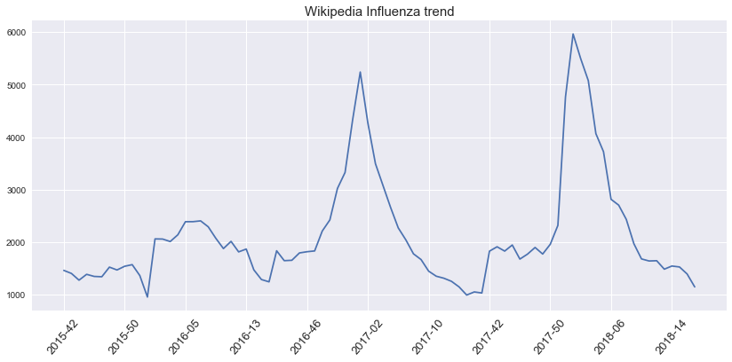

```python
plot(df, label2="Influenza")
```

How we expected, during the winter seasons we have an increment of the pageviews

## Part 1.2

### Comparing time series from the Official Influnet surveillance system with the time series of pageviews

Since the Official data were relased in PDF, we converted the file in txt.

- Read files

```python
influ_2015_2016=influnet("influnet_2015-2016")
influ_2016_2017=influnet("influnet_2016-2017")
influ_2017_2018=influnet("influnet_2017-2018", level1="Settimana", level2="Casi")
```

```python
# create a new dataframe
data=[influ_2015_2016,influ_2016_2017,influ_2017_2018]
df2=pd.concat(data)
df2.reset_index(inplace=True)
df2.drop("index", axis=1, inplace=True)
```

```python
#for the sake of simplicity add a column with year
year=[]
for i in df2['Date iso week']:
    year.append(i[:4])
df2['year']=year
```

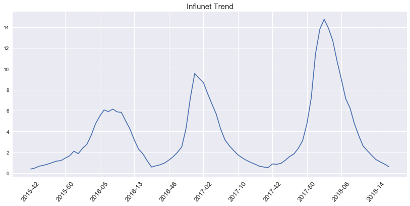

```python
plot(df2,label2="Incidenza totale",title=0)
```

```python
#Create a new dataframe and rescale data
df3=df2.merge(df,on = "Date iso week")
df3_n=normalize(df3,["Incidenza totale","Influenza"])
```

- Plot influnet data (total incidence) and Influenza data pageviews

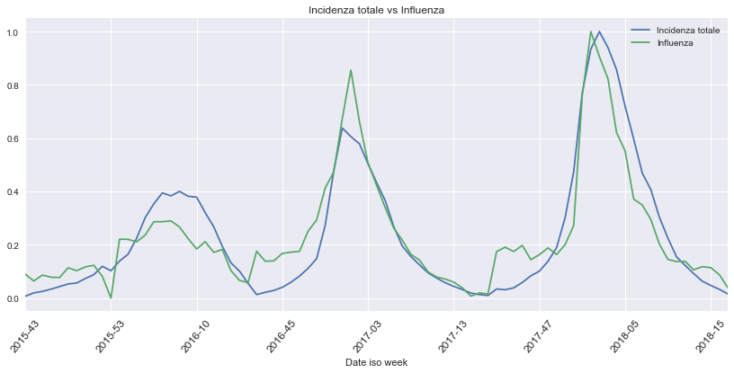

```
Pearson Correlation:
                   Incidenza totale  Influenza
Incidenza totale           1.00000    0.92039
Influenza                  0.92039    1.00000
```

```python
plot(df3_n,label2=["Incidenza totale","Influenza"],typ=2)
```

Overlapping the two trends they seems to have the same behaviour.

That is confirmed by the Pearson correlation as the table above shows.

# Part 2

## Part 2.1 & 2.2

### Find other Wikipedia pages related to flu whose pageview time series are correlated with the Influnet signal

To identify the pages we did the following steps:

- We took from the page Influenza of Wikipedia all the links that refer to other pages
- Data preprocessing
- Using **wordnet** packages we compare "Influenza" with all the other words taken from the scraping $\rightarrow$ have been considered only the words with correlation $\ge$ 0.85
- Add other words based on our personal intuition

```python
#scraping
root_url = "https://it.wikipedia.org"
page_url = root_url + "/wiki/Influenza"
r = requests.get(page_url).text
soup = bs4.BeautifulSoup(r, "lxml")
My_table = soup.find("div",{"class":"mw-parser-output"})
links = My_table.find_all("a")
disease = [link.get("title") for link in links]
scrape = pd.DataFrame()
scrape["Disease"] = disease
scrape.dropna(inplace=True)
scrape.drop_duplicates(inplace=True)
```

```python
#Preprocessing data
lista=list(scrape["Disease"])
deli=[x for x in lista if x.startswith('1') or x.startswith("Template") or x.startswith("Discussioni") or x.startswith("Collabora") or x.startswith("d:Q2840") or x.startswith("Digital object identifier") or x.startswith("q:") or x.startswith("wikt") or x.startswith('8') or x.startswith('978') or x.startswith('20') or x.startswith('5') or x.startswith('6') or x.startswith('Wiki') or x.startswith("Modifica") or x.startswith("Speciale") or x.startswith("Aiuto")]
parole=set(lista)-set(deli)
parole=[i for i in parole]
words=[]
for i in parole:
    words.append(re.sub(re.compile('la pagina non esiste'),'',i))

parole_final=[]
for j in words:
    parole_final.append(re.sub(r'\([^)]*\)','',j))
parole_final.insert(0,"Influenza")
parole_final.sort()
```

```python
influ = wn.synset('influenza.n.01')
similarity_list = {}
for i in parole_final:
    term_list = wn.synsets(i, lang = "ita")
    temp = [influ.wup_similarity(p) for p in term_list]
    if len(temp) != 0:
        try:
            if max(temp) >= 0.85:
                similarity_list.update({i: max(temp)})
        except:
            pass
simi = dict(sorted(similarity_list.items(), key=lambda x: x[1], reverse=True)[1:])
corr=[round(i,3) for i in simi.values()]
name=[i for i in simi.keys()]
simi=dict(zip(name,corr))
print("The most correlated words are: ", simi)
```

```
The most correlated words are:  {'Contagio': 0.96, 'Difterite': 0.923, 'Morbillo': 0.923, 'Asma': 0.917, 'Bronchite': 0.917, 'Enfisema': 0.917, 'Polmonite': 0.917, 'Malattia': 0.909, 'Antracosi': 0.88, 'Siderosi': 0.88, 'Silicosi': 0.88, 'Epatopatia': 0.87}
```

```python
parole_scelte_1=list(simi.keys())
parole_scelte_2=['Oseltamivir','Pandemia influenzale','Influenza asiatica','Zanamivir','Paracetamolo','Bronchiolite',"Febbre","Vaccino antinfluenzale"]
parole_scelte=parole_scelte_1+parole_scelte_2
```

Here we show all the selected words

```python
print("List of words:", *parole_scelte, sep="\n ")
```

```
List of words:
 Contagio
 Difterite
 Morbillo
 Asma
 Bronchite
 Enfisema
 Polmonite
 Malattia
 Antracosi
 Siderosi
 Silicosi
 Epatopatia
 Oseltamivir
 Pandemia influenzale
 Influenza asiatica
 Zanamivir
 Paracetamolo
 Bronchiolite
 Febbre
 Vaccino antinfluenzale
```

For each selected word if the correlation with Influnet trend is $\ge$ 0.75 we make a plot with Influnet time series

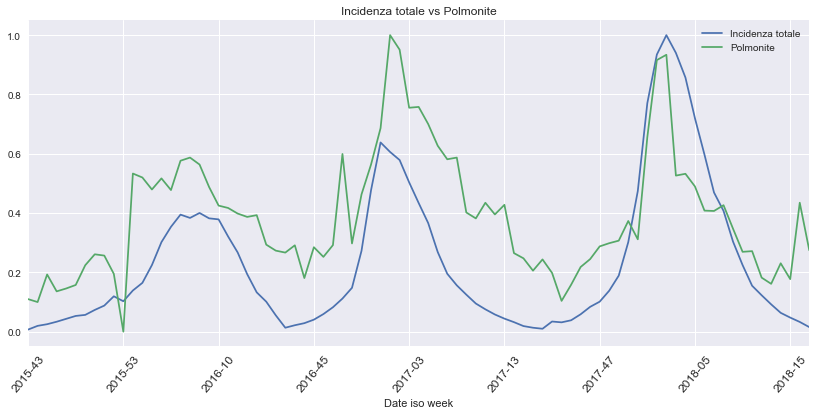

```
Pearson Correlation:
                   Incidenza totale  Influenza  Polmonite
Incidenza totale          1.000000   0.920390   0.750521
Influenza                 0.920390   1.000000   0.793172
Polmonite                 0.750521   0.793172   1.000000
```

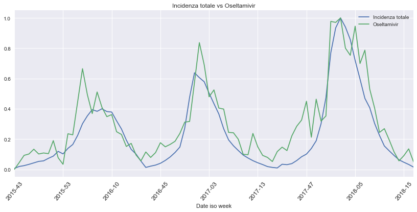

```
Pearson Correlation:
                   Incidenza totale  Influenza  Oseltamivir
Incidenza totale          1.000000   0.920390     0.918348
Influenza                 0.920390   1.000000     0.882979
Oseltamivir               0.918348   0.882979     1.000000
```

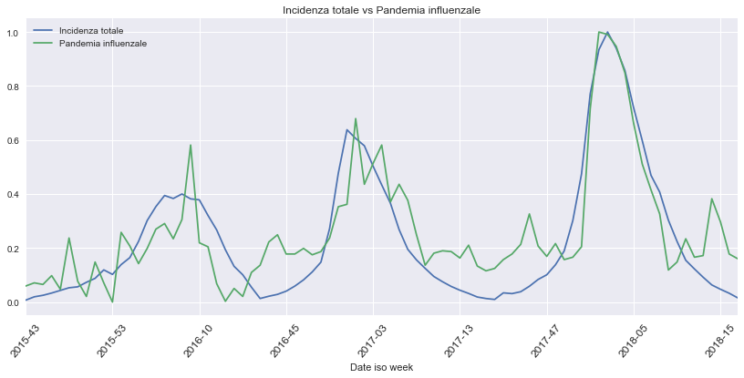

```
Pearson Correlation:
                       Incidenza totale  Influenza  Pandemia influenzale
Incidenza totale              1.000000   0.920390              0.860479
Influenza                     0.920390   1.000000              0.879091
Pandemia influenzale          0.860479   0.879091              1.000000
```

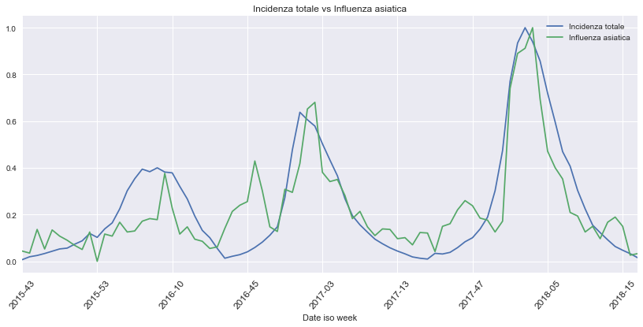

```
Pearson Correlation:
                     Incidenza totale  Influenza  Influenza asiatica
Incidenza totale            1.000000   0.920390            0.854606
Influenza                   0.920390   1.000000            0.912348
Influenza asiatica          0.854606   0.912348            1.000000
```

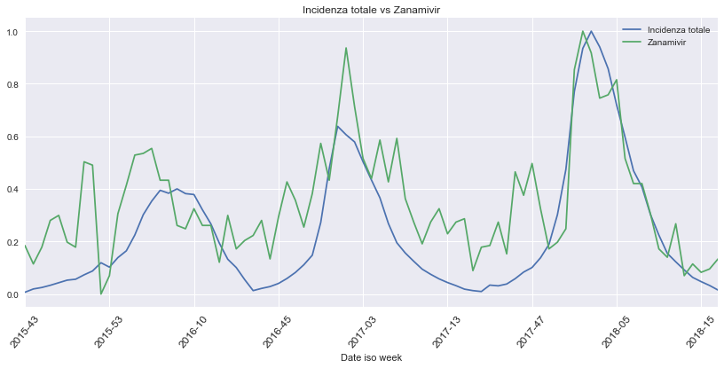

```
Pearson Correlation:
                   Incidenza totale  Influenza  Zanamivir
Incidenza totale          1.000000   0.920390   0.795457
Influenza                 0.920390   1.000000   0.868284
Zanamivir                 0.795457   0.868284   1.000000
```

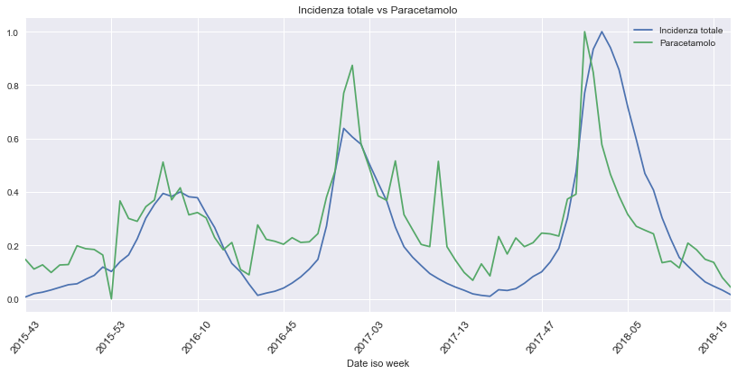

```
Pearson Correlation:
                   Incidenza totale  Influenza  Paracetamolo
Incidenza totale          1.000000   0.920390      0.768056
Influenza                 0.920390   1.000000      0.855857
Paracetamolo              0.768056   0.855857      1.000000
```

```python
correlazioni={}

for i in range(len(parole_scelte)):
    path="more "+"(%s)"%(1+i)+".csv"
    parola=parole_scelte[i]
    df=pd.read_csv(path)
    sum_iso_week=iso_week(df)
    date_15=data_years(sum_iso_week,2015)
    date_15=date_15[15:]
    date_16=data_years(sum_iso_week,2016)
    date_16=pd.concat([date_16[:16],date_16[41:52]])
    date_17=data_years(sum_iso_week,2017)
    date_17=pd.concat([date_17[:17],date_17[41:]])
    date_18=data_years(sum_iso_week,2018)
    date_18=date_18[:17]
    data=[date_15,date_16,date_17,date_18]
    df=pd.concat(data)
    df.reset_index(inplace=True)
    df.drop("index", axis=1, inplace=True)
    df3=df2.merge(df,on = "Date iso week")
    df3=normalize(df3, ["Incidenza totale",parole_scelte[i]])
    # Compute correlations and plot words with corr > 0.75
    corre=df3.corr(method="pearson")["Incidenza totale"][2]
    if corre > 0.75:
        corr=plot(df3,label2=["Incidenza totale",parole_scelte[i]],typ=1)

    correlazioni[parola]={"Word":parola,"Correlation":corre,"Path":path}
```

```python
correlations=[]
for a, b in correlazioni.items():
    if b["Correlation"] > 0.75:
        correlations.append([b["Word"],b["Correlation"]])

correlations.sort(key=lambda x: x[1], reverse=True)
wor=[item[0] for item in correlations]
print("Most correlated words:", *wor, sep="\n ")
```

```
Most correlated words:
 Oseltamivir
 Pandemia influenzale
 Influenza asiatica
 Zanamivir
 Paracetamolo
 Polmonite
```

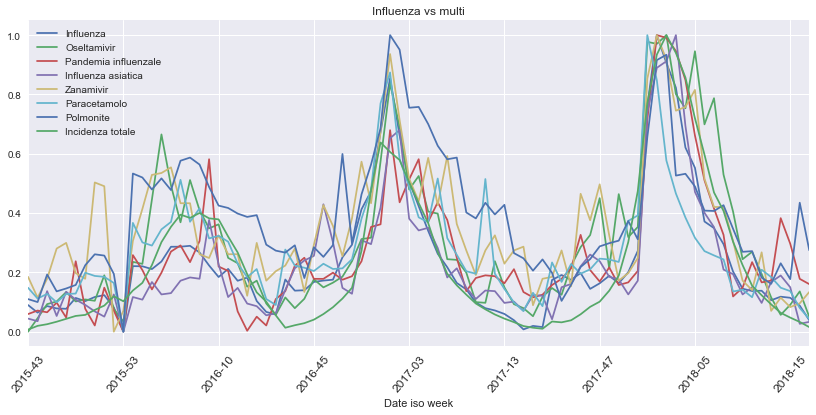

|  | Influenza | Oseltamivir | Pandemia influenzale | Influenza asiatica | Zanamivir | Paracetamolo | Polmonite | Incidenza totale |
| --- | --- | --- | --- | --- | --- | --- | --- | --- |
| Influenza | 1.000000 | 0.882979 | 0.879091 | 0.912348 | 0.868284 | 0.855857 | 0.793172 | 0.920390 |
| Oseltamivir | 0.882979 | 1.000000 | 0.825224 | 0.823701 | 0.849912 | 0.752271 | 0.738510 | 0.918348 |
| Pandemia influenzale | 0.879091 | 0.825224 | 1.000000 | 0.908245 | 0.770538 | 0.702701 | 0.695354 | 0.860479 |
| Influenza asiatica | 0.912348 | 0.823701 | 0.908245 | 1.000000 | 0.804905 | 0.731923 | 0.673207 | 0.854606 |
| Zanamivir | 0.868284 | 0.849912 | 0.770538 | 0.804905 | 1.000000 | 0.770913 | 0.753224 | 0.795457 |
| Paracetamolo | 0.855857 | 0.752271 | 0.702701 | 0.731923 | 0.770913 | 1.000000 | 0.805819 | 0.768056 |
| Polmonite | 0.793172 | 0.738510 | 0.695354 | 0.673207 | 0.753224 | 0.805819 | 1.000000 | 0.750521 |
| Incidenza totale | 0.920390 | 0.918348 | 0.860479 | 0.854606 | 0.795457 | 0.768056 | 0.750521 | 1.000000 |

```python
#Read multi-words file
multi=pd.read_csv('multi.csv')
multi=iso_week(multi)
date_15_2=data_years(multi,2015)
date_15_2=date_15_2[15:]
date_16_2=data_years(multi,2016)
date_16_2=pd.concat([date_16_2[:16],date_16_2[41:52]])
date_17_2=data_years(multi,2017)
date_17_2=pd.concat([date_17_2[:17],date_17_2[41:]])
date_18_2=data_years(multi,2018)
date_18_2=date_18_2[:17]
data=[date_15_2,date_16_2,date_17_2,date_18_2]
df4=pd.concat(data)
df4.reset_index(inplace=True)
df4.drop("index", axis=1, inplace=True)
df5=df4.merge(df2,on = "Date iso week")
df5.drop("year_x",axis=1, inplace=True)
df5.drop("year_y",axis=1, inplace=True)

#Normalize data and plot
df5=normalize(df5,['Influenza', 'Oseltamivir', 'Pandemia influenzale','Influenza asiatica', 'Zanamivir', 'Paracetamolo', 'Polmonite','Incidenza totale'])
plot(df5, label2=['Influenza', 'Oseltamivir','Pandemia influenzale','Influenza asiatica','Zanamivir', 'Paracetamolo', 'Polmonite','Incidenza totale'], typ=3)
df5.corr()
```

As we can see from the table, "**Influenza**" remains the word with the highest correlation ($0.920$) followed by "**Oseltamivir**" ($0.918$), an antiviral drug for the treatment and prophylaxis of influenza A and B. This drug, like also Zanamivir, is "Wikipediato" just when influenza peaks are occured.

Even the other words are almost totally sought only in the flu periods, this justifies the high correlation.

In the list of the most correlated words we do not find "Vaccino antinfluenzale". Thus, we have decided to check the trend and correlation manually

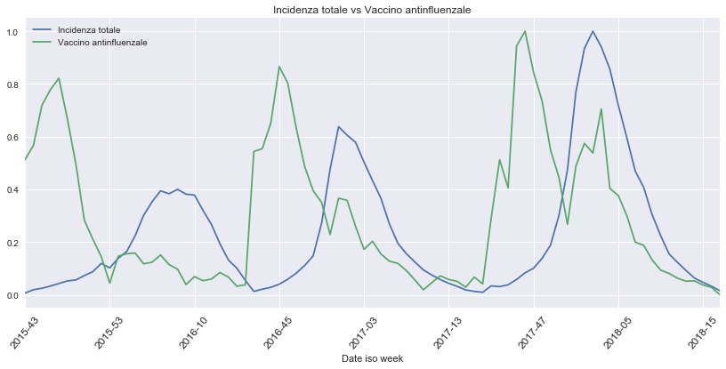

```
Pearson Correlation:
                         Incidenza totale  Influenza  Vaccino antinfluenzale
Incidenza totale                1.000000   0.920390                0.020512
Influenza                       0.920390   1.000000                0.196655
Vaccino antinfluenzale          0.020512   0.196655                1.000000
```

```python
path="more "+"(%s)"%(20)+".csv"
df=pd.read_csv(path)
sum_iso_week=iso_week(df)
date_15=data_years(sum_iso_week,2015)
date_15=date_15[15:]
date_16=data_years(sum_iso_week,2016)
date_16=pd.concat([date_16[:16],date_16[41:52]])
date_17=data_years(sum_iso_week,2017)
date_17=pd.concat([date_17[:17],date_17[41:]])
date_18=data_years(sum_iso_week,2018)
date_18=date_18[:17]
data=[date_15,date_16,date_17,date_18]
df=pd.concat(data)
df.reset_index(inplace=True)
df.drop("index", axis=1, inplace=True)
df3=df2.merge(df,on = "Date iso week")
df3=normalize(df3, ["Incidenza totale","Vaccino antinfluenzale"])
corre=df3.corr(method="pearson")["Incidenza totale"][2]
corr=plot(df3,label2=["Incidenza totale","Vaccino antinfluenzale"],typ=2)
```

The correlation is very low ($0.020512$). The trend seems to be shifted by at least one month previous weeks. This might be generated by the fact that the vaccination campaign is always programmed weeks before the influence trend

# Part 3

## Part 3.1

### Build a regression model that predicts the Influnet incidence based on the Wikipedia pageview data

```python
# Preprocessing data to build up the model thanks to cross-validation approach
df5=df5[1:]
X = df5.drop(["Incidenza totale","Date iso week"], axis = 1)
y = df5["Incidenza totale"]
date=df5["Date iso week"]
```

We decided to use differents models to predict Influnet trend. The model used are:

- Linear regression
- Ridge
- Lasso
- Random forest
- Gradient Boosting
- Kernel Ridge

```python
# Find and store error, and predictions for each model
val=[]
df_fin=[]
pred_y=[]
for i in range(1,7):

    p,df,p_y=model_analysis(i,X,y,date,plots=False)
    val.append(p)
    df_fin.append(df)
    pred_y.append(p_y)



p7,dfd_7,p_y_7=model_mix(val[5],val[4],pred_y[5],pred_y[4],X,y,date,"Gradient Boosting and Kernel Ridge",plots=False,perc_mod_1=0.5,perc_mod_2=0.5)
val.append(p7)
df_fin.append(dfd_7)
pred_y.append(p_y_7)

#Create a dataframe with all the values
result = pd.concat(df_fin)
result
```

| Model | MAE Test | MAE Total | R2 Test | R2 Total | RMSE Test | RMSE Total |
| --- | --- | --- | --- | --- | --- | --- |
| Linear Regression | 0.069307 | 0.059805 | 0.903005 | 0.899383 | 0.091427 | 0.077323 |
| Ridge | 0.069381 | 0.059847 | 0.902855 | 0.899308 | 0.091498 | 0.077351 |
| Lasso | 0.069315 | 0.059810 | 0.902990 | 0.899376 | 0.091435 | 0.077326 |
| Random Forest | 0.079252 | 0.040967 | 0.869611 | 0.927394 | 0.106004 | 0.065684 |
| Gradient Boosting | 0.072008 | 0.024759 | 0.884250 | 0.942676 | 0.099876 | 0.058363 |
| Kernel Ridge | 0.069570 | 0.037442 | 0.904556 | 0.943441 | 0.090694 | 0.057973 |
| Gradient Boosting and Kernel Ridge | 0.069212 | 0.030521 | 0.908846 | 0.952506 | 0.088632 | 0.053124 |

We stored the MSE and the R2 measure for each of the model in the table above.

Excluding the last one model, that is a mix of Gradient Boosting and Kernel Ridge (we will talk about it later on), based on R2 we can see how the best model turned out to be the Kernel Ridge.

The R2 measure indicates that the model explains more than 94% variability of the response data around its mean.

Given that this model concurrently with the Gradient Boosting are the best for our purpose, we decided to mix them to check if we were able to increment the R2 measure.

The Result seems to be quite good with respect to the single models.

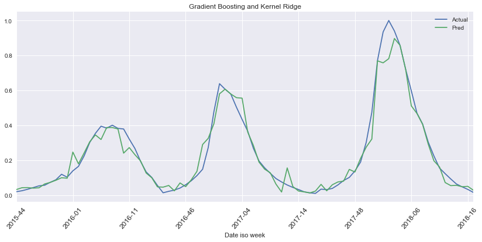

```
Pearson Correlation:
 0.978100008072
R2 Test:  0.90884560768
RMSE Test:  0.0886320446661
R2 Total:  0.952505538582
RMSE Total:  0.0531242127938
Test Mean Absolute Error:  0.0692119365395
Total Mean Absolute Error:  0.0305211244546
```

```python
p7,dfd_7,p_y_7=model_mix(val[5],val[4],pred_y[5],pred_y[4],X,y,date,"Gradient Boosting and Kernel Ridge",plots=True,perc_mod_1=0.5,perc_mod_2=0.5)
```

## Part 3.2

### To improve our model we add these features:

- The Influnet incidence for the week preceding the target week
- The pageview counts for all the pages you selected for the week preceding the target week

```python
# Merge previous week data with target week
influ_prec=(df5["Influenza"][:-1])
Oseltamivir_prec=(df5["Oseltamivir"][:-1])
Pandemia_influenzale_prec=(df5["Pandemia influenzale"][:-1])
Influenza_asiatica_prec=(df5["Influenza asiatica"][:-1])
Zanamivir_prec=(df5["Zanamivir"][:-1])
Paracetamolo_prec=(df5["Paracetamolo"][:-1])
Polmonite_prec=(df5["Polmonite"][:-1])
inci_prec=(df5["Incidenza totale"][:-1])

date_prec=df5["Date iso week"][1:]
aa=pd.DataFrame(list(map(list, zip(date_prec,influ_prec,Oseltamivir_prec,Pandemia_influenzale_prec,Influenza_asiatica_prec,
                                  Zanamivir_prec,Paracetamolo_prec,Polmonite_prec,inci_prec))))
aa.columns = ['Date iso week',"Influenza precedente", "Oseltamivir precedente","Pandemia influenzale precedente","Influenza asiatica precedente",
             "Zanamivir precedente","Paracetamolo precedente","Polmonite precedente","Incidenza totale precedente"]
```

```python
df5=df5[1:]
df5_bis=aa.merge(df5,on = "Date iso week")
```

```python
# Preprocessing data to build up the model thanks to cross-validation approach
X_bis = df5_bis.drop(["Incidenza totale","Date iso week"], axis = 1)
y_bis = df5_bis["Incidenza totale"]
```

```python
# Find and store error, and predictions for each model

val_bis=[]
df_fin_bis=[]
pred_y_bis=[]
for i in range(6):
    p,df,p_y=model_analysis(i+1,X_bis,y_bis,date,plots=False)
    val_bis.append(p)
    df_fin_bis.append(df)
    pred_y_bis.append(p_y)

p7_bis,dfd_7_bis,p_y_7_bis=model_mix(val_bis[5],val_bis[4],pred_y_bis[5],pred_y_bis[4],X_bis,y_bis,date,"Gradient Boosting and Kernel Ridge",plots=False,perc_mod_1=0.5,perc_mod_2=0.5)
val_bis.append(p7_bis)
df_fin_bis.append(dfd_7_bis)
pred_y_bis.append(p_y_7_bis)

result = pd.concat(df_fin_bis)
result
```

| Model | MAE Test | MAE Total | R2 Test | R2 Total | RMSE Test | RMSE Total |
| --- | --- | --- | --- | --- | --- | --- |
| Linear Regression | 0.046644 | 0.030928 | 0.927783 | 0.964795 | 0.066269 | 0.045791 |
| Ridge | 0.046698 | 0.030937 | 0.927644 | 0.964747 | 0.066333 | 0.045823 |
| Lasso | 0.046643 | 0.030928 | 0.927761 | 0.964787 | 0.066280 | 0.045796 |
| Random Forest | 0.055846 | 0.028347 | 0.887397 | 0.956334 | 0.082750 | 0.050998 |
| Gradient Boosting | 0.057166 | 0.019224 | 0.874610 | 0.957324 | 0.087322 | 0.050416 |
| Kernel Ridge | 0.051272 | 0.018713 | 0.877149 | 0.958079 | 0.086434 | 0.049969 |
| Gradient Boosting and Kernel Ridge | 0.050719 | 0.017769 | 0.888448 | 0.962004 | 0.082363 | 0.047572 |

We noticed that adding the data from the previous week, the linear regression model, Lasso and Ridge improved their performance while with the Gradient Boosting, the Random Forest and the Kernel Ridge the results have not increased so much.

According to the table above shown it turned out to be that according to R2, the best model is the Linear Regression one and we plot this latter.

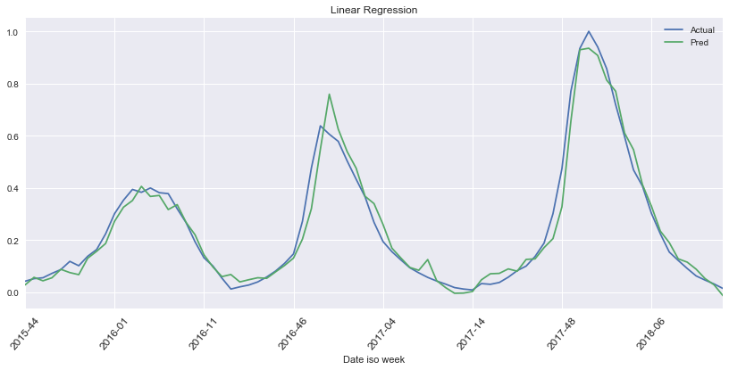

```
Pearson Correlation:
 0.981979264124
R2 Test:  0.927783378373
RMSE Test:  0.0662694327098
R2 Total:  0.964795094406
RMSE Total:  0.045791143347
Test Mean Absolute Error:  0.0466438456514
Total Mean Absolute Error:  0.0309283377368
```

```python
p,df,p_y=model_analysis(1,X_bis,y_bis,date,plots=True)
```

With this new one the results seem to be better as we can see from the plot below.

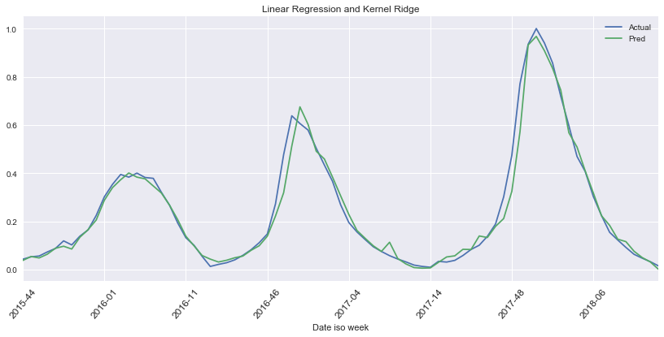

```
Pearson Correlation:
 0.98583542452
R2 Test:  0.921646550854
RMSE Test:  0.0690277517433
R2 Total:  0.970527055783
RMSE Total:  0.0418978421749
Test Mean Absolute Error:  0.044061515836
Total Mean Absolute Error:  0.0226480495845
```

```python
p8_bis,dfd_8_bis,p_y_8_bis=model_mix(val_bis[0],val_bis[6],pred_y_bis[0],pred_y_bis[6],X_bis,y_bis,date,"Linear Regression and Kernel Ridge",plots=True,perc_mod_1=0.5,perc_mod_2=0.5)
```

### 2018 Prediction

Now we've decided to approach our problem in a different point of view. While on the previous models our train and test set have been chosen in a randomly way, in this case the train set is composed by all the data from 2015 to 2017 to predict 2018.

```python
x_train_3=df5_bis[1:63]
x_test_3=df5_bis[64:]

y_train_3 = x_train_3["Incidenza totale"]
x_train_3.drop(["Incidenza totale","Date iso week"], axis = 1,inplace=True)

y_test_3 = x_test_3["Incidenza totale"]
x_test_3.drop(["Incidenza totale","Date iso week"], axis = 1,inplace=True)
```

```python
# Find and store error, and predictions for each model

val_bis=[]
df_fin_bis=[]
pred_y_bis=[]
for i in range(7):
    p,df,p_y=model_analysis_2018(i+1,x_train_3,x_test_3,y_train_3,y_test_3,date,X_bis,y_bis,plots=False)
    val_bis.append(p)
    df_fin_bis.append(df)
    pred_y_bis.append(p_y)

p7_bis,dfd_7_bis,p_y_7_bis=model_mix_2018(val_bis[0],val_bis[4],pred_y_bis[0],pred_y_bis[4],x_train_3,y_train_3,x_test_3,y_test_3,date,X_bis,y_bis,"Linear Regression and Gradient Boosting",plots=False,perc_mod_1=0.85,perc_mod_2=0.15)
val_bis.append(p7_bis)
df_fin_bis.append(dfd_7_bis)
pred_y_bis.append(p_y_7_bis)

result = pd.concat(df_fin_bis)
result
```

| Model | MAE Test | MAE Total | R2 Test | R2 Total | RMSE Test | RMSE Total |
| --- | --- | --- | --- | --- | --- | --- |
| Linear Regression | 0.054374 | 0.033085 | 0.965877 | 0.962760 | 0.064652 | 0.047096 |
| Ridge | 0.054328 | 0.033081 | 0.965886 | 0.962709 | 0.064643 | 0.047128 |
| Lasso | 0.054362 | 0.033083 | 0.965882 | 0.962756 | 0.064647 | 0.047098 |
| Random Forest | 0.134164 | 0.040582 | 0.681284 | 0.848769 | 0.197587 | 0.094908 |
| Gradient Boosting | 0.130016 | 0.029220 | 0.706703 | 0.869320 | 0.189544 | 0.088224 |
| Kernel Ridge | 0.151846 | 0.038212 | 0.484576 | 0.760752 | 0.251269 | 0.119372 |
| Kernel Ridge - Bis | 0.074265 | 0.037676 | 0.904238 | 0.936400 | 0.108306 | 0.061547 |
| Linear Regression and Gradient Boosting | 0.054711 | 0.030167 | 0.959634 | 0.965388 | 0.070318 | 0.045404 |

Even in this case, the Linear Regression turned out to be the best model (always based on the R2 measure). Again we mixed two models (Linear Regression and Gradient Boosting) giving more weight to the Linear in such a way to obtain better results.

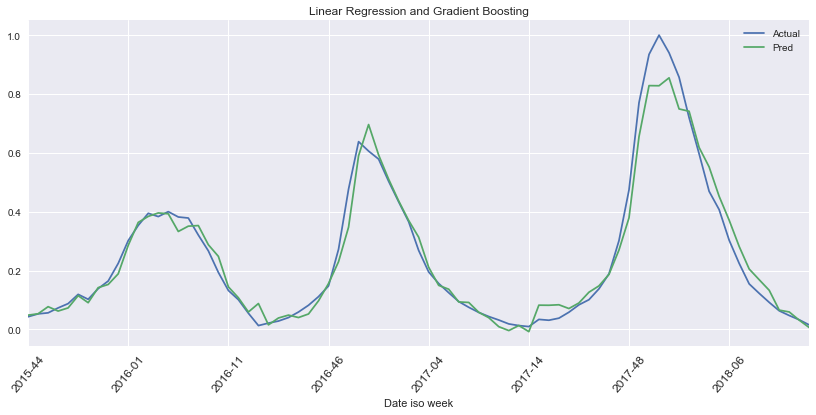

```
Pearson Correlation:
 0.984265157851
R2 Test:  0.959633590657
RMSE Test:  0.0703180249709
R2 Total:  0.965387810375
RMSE Total:  0.0454040332041
Test Mean Absolute Error:  0.0547110288238
Total Mean Absolute Error:  0.0301666325202
```

```python
p7_bis,dfd_7_bis,p_y_7_bis=model_mix_2018(val_bis[0],val_bis[4],pred_y_bis[0],pred_y_bis[4],x_train_3,y_train_3,x_test_3,y_test_3,date,X_bis,y_bis,"Linear Regression and Gradient Boosting",plots=True,perc_mod_1=0.85,perc_mod_2=0.15)
```